# Accessing NYT API for analysis of the term domestic terrorist

Justin Herman

March 27, 2018

```r
#rm(list=ls())
#install.packages("devtools")
#devtools::install_github("mkearney/nytimes")
library(data.table)
library(plyr)
library(tidyverse)
library(splitstackshape)
```

```r
library(magrittr)
library(rlang)
library(gridExtra)
library(knitr)
library(kableExtra)
library(data.table)
library(ggplot2)
library(RCurl)
library(httr)
library(rtimes)
library(jsonlite)
library(tidyverse)
```

### Intro

- I found a really useful guide to accessing NYT API here http://www.storybench.org/working-with-the-new-york-times-api-in-r/

## Set up a times key(doesn’t print)—–

## Initial attempt

- This attempt was a failure in that it returned too many results
- I attmepted to use date filter

```r
term <- "domestic+terrorist"
begin_date <- "20000420"
end_date <- "20160428"

baseurl <- paste0("http://api.nytimes.com/svc/search/v2/articlesearch.json?fq=body=",term,
                  "&begin_date=",begin_date,"&end_date=",end_date,
                  "&facet_filter=true&api-key=",NYTIMES_KEY, sep="")



initialQuery <- fromJSON(baseurl)
initialQuery[[3]][2]
```

```
## $meta
## $meta$hits
## [1] 191555
##
## $meta$offset
## [1] 0
##
## $meta$time
## [1] 31
```

```r
Sys.sleep(1)
```

## ATTEMPT 2

- Gabrielle helped me to understand how to query for multiple word phrases
- Get request gives me an idea of my query limits

```r
### another way

new_search <- "\"domestic terrorist\""
articleSearchURL <- "http://api.nytimes.com/svc/search/v2/articlesearch.json"
APIquery <- list("api-key"=NYTIMES_KEY,'q'=new_search)
rawArticle <- GET(articleSearchURL, query = APIquery)
rawArticle[[3]]
```

```
## $`content-type`
## [1] "application/json;charset=UTF-8"
##
## $date
## [1] "Fri, 30 Mar 2018 14:13:01 GMT"
##
## $server
## [1] "nginx/1.12.2"
##
## $via
## [1] "kong/0.9.5"
##
## $`x-kong-proxy-latency`
## [1] "46"
##
## $`x-kong-upstream-latency`
## [1] "66"
##
## $`x-ratelimit-limit-day`
## [1] "1000"
##
## $`x-ratelimit-limit-second`
## [1] "1"
##
## $`x-ratelimit-remaining-day`
## [1] "559"
##
## $`x-ratelimit-remaining-second`
## [1] "0"
##
## $`transfer-encoding`
## [1] "chunked"
##
## $connection
## [1] "keep-alive"
##
## attr(,"class")
## [1] "insensitive" "list"
```

```r
Sys.sleep(1)
```

## Using my initial api request with correct search terms

- Encode the url becuase the term had a space

```r
orig_url<- "http://api.nytimes.com/svc/search/v2/articlesearch.json?api-key="
term <- "\"domestic terrorist\""
baseurl <- paste0(orig_url,
                  NYTIMES_KEY,
                  '&q=',term,
                  "&facet_filter=true", sep="")

baseurl <- URLencode(baseurl)
initialQuery <- fromJSON(baseurl)
Sys.sleep(1)
initialQuery[[3]][2]
```

```
## $meta
## $meta$hits
## [1] 247
##
## $meta$offset
## [1] 0
##
## $meta$time
## [1] 55
```

- This worked and my query shows me that there are 247 repsonses
- In the next section I will loop through an api request and get all 247 responses

## Create loop to record all metadata

- I took the loop from the walk through I posted earlier

```r
domestic_terroirst <- list()
for(i in 0:24){
  nytSearch <- fromJSON(paste0(baseurl, "&page=", i), flatten = TRUE) %>%     data.frame()
  domestic_terroirst[[i+1]] <- nytSearch
  Sys.sleep(1)
}
```

## Build df by rbinding the results from the loop

- Display column names

```r
domestic_terroirst_df <- rbind_pages(domestic_terroirst)
head(domestic_terroirst_df)
```

```
##   status
## 1     OK
## 2     OK
## 3     OK
## 4     OK
## 5     OK
## 6     OK
##                                                             copyright
## 1 Copyright (c) 2018 The New York Times Company. All Rights Reserved.
## 2 Copyright (c) 2018 The New York Times Company. All Rights Reserved.
## 3 Copyright (c) 2018 The New York Times Company. All Rights Reserved.
## 4 Copyright (c) 2018 The New York Times Company. All Rights Reserved.
## 5 Copyright (c) 2018 The New York Times Company. All Rights Reserved.
## 6 Copyright (c) 2018 The New York Times Company. All Rights Reserved.
##                                                                             response.docs.web_url
```

[output cut: 132 more lines]

```r
rm(domestic_terroirst)
```

## Exploratory analysis

- I love this chooseone function, credit to Amber Thomas, she provided it in a kaggle competition and I used it in project 3
- I lapply it for some summary analysis

```r
chooseOne = function(question){
    domestic_terroirst_df %>%
        filter(!UQ(sym(question)) == "") %>%
        dplyr::group_by_(question) %>%
        dplyr::summarise(count = n()) %>%
        dplyr::mutate(percent = (count / sum(count)) * 100) %>%
        dplyr::arrange(desc(count))
}
my_names <- colnames(domestic_terroirst_df)
the_names <- my_names[(c(2,3,10,11,12,15,19,20,25))]
lapply(the_names,function(x)chooseOne(x))
```

```
## [[1]]
## # A tibble: 1 x 3
##   copyright                                                   count perce~
##   <fctr>                                                      <int>  <dbl>
## 1 Copyright (c) 2018 The New York Times Company. All Rights ~   247    100
##
## [[2]]
## # A tibble: 243 x 3
##    response.docs.web_url                                      count perce~
##    <chr>                                                      <int>  <dbl>
##  1 https://artsbeat.blogs.nytimes.com/2010/05/03/the-return-~     2  0.810
##  2 https://cityroom.blogs.nytimes.com/2011/09/29/a-tribute-t~     2  0.810
##  3 https://www.nytimes.com/2009/12/20/opinion/20rich.html         2  0.810
##  4 https://www.nytimes.com/2012/05/21/world/europe/italian-s~     2  0.810
##  5 https://atwar.blogs.nytimes.com/2009/12/09/american-suppo~     1  0.405
##  6 https://bittman.blogs.nytimes.com/2013/09/10/on-911-my-tw~     1  0.405
##  7 https://carpetbagger.blogs.nytimes.com/2010/12/01/a-new-c~     1  0.405
##  8 https://douthat.blogs.nytimes.com/2010/11/30/how-partisan~     1  0.405
##  9 https://economix.blogs.nytimes.com/2013/08/12/the-fiscal-~     1  0.405
## 10 https://ethicist.blogs.nytimes.com/2009/11/17/free-speech~     1  0.405
## # ... with 233 more rows
##
## [[3]]
## # A tibble: 29 x 3
##    response.docs.new_desk count percent
##    <chr>                  <int>   <dbl>
##  1 National Desk             48   22.7
##  2 National                  32   15.2
##  3 Foreign                   22   10.4
##  4 OpEd                      19    9.00
##  5 Metropolitan Desk         14    6.64
##  6 Foreign Desk              12    5.69
##  7 Editorial Desk            10    4.74
##  8 Metro                      7    3.32
##  9 Culture                    6    2.84
## 10 Editorial                  6    2.84
## # ... with 19 more rows
##
## [[4]]
## # A tibble: 15 x 3
```

[output cut: 75 more lines]

```
##  6 THREATS AND RESPONSES: DOMESTIC SECURITY     3    2.80
##  7 ArtsBeat                                     2    1.87
##  8 City Room                                    2    1.87
##  9 Editorial                                    2    1.87
## 10 India Ink                                    2    1.87
## # ... with 66 more rows
##
## [[9]]
## # A tibble: 4 x 3
##   response.docs.headline.sub                                  count perce~
##   <chr>                                                       <int>  <dbl>
## 1 6 Arrested in Canada Raid Attended the Same Mosque              1   25.0
## 2 A Plague of Stunt Casting Is Being Spread Over the Airwave~     1   25.0
## 3 Bank Data Is Sifted by U.S. in Secret to Block Terror           1   25.0
## 4 Lawmaker Will Begin Look Into Homegrown Islamic Terrorism;      1   25.0
```

## Create visual displays

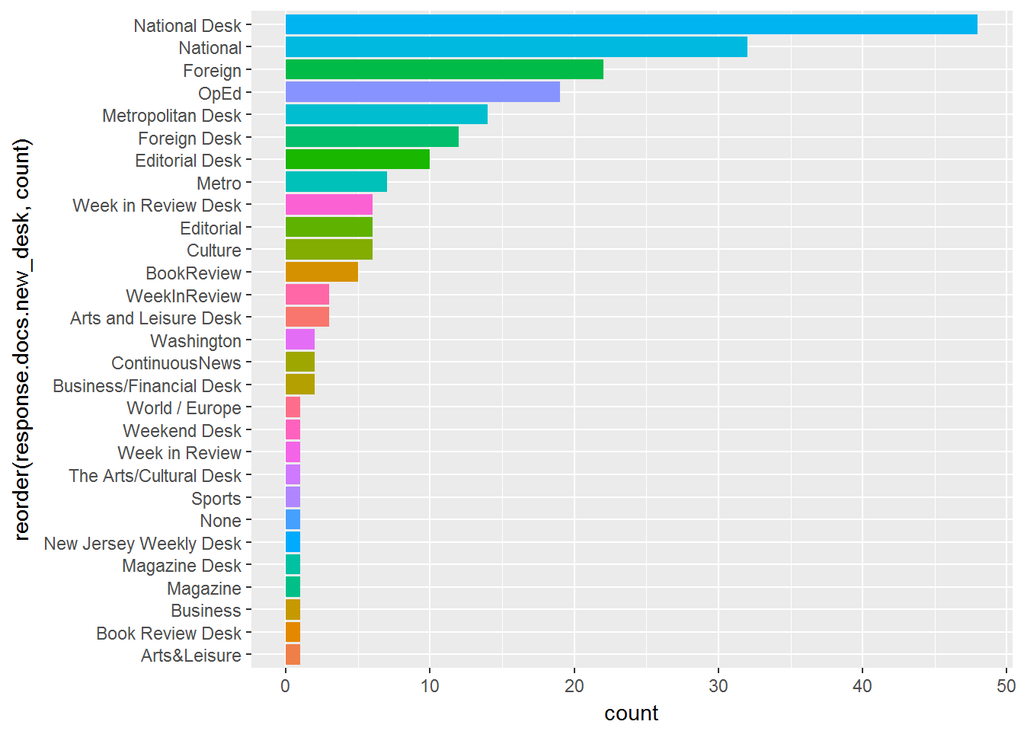

```r
domestic_terroirst_df %>%
  filter(!UQ(sym('response.docs.new_desk')) == "") %>%
  dplyr::group_by(response.docs.new_desk) %>%
  dplyr::summarize(count=n()) %>%
  ggplot() +
  geom_bar(aes(y=count, x=reorder(response.docs.new_desk,count), fill=fct_infreq(response.docs.new_desk)), stat = "identity") +
    coord_flip()+
    theme(legend.position="none")
```

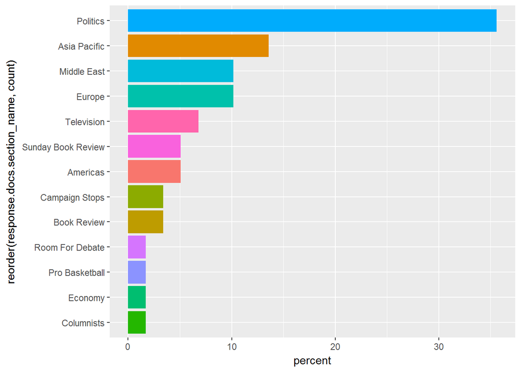

```r
domestic_terroirst_df %>%
  filter(!UQ(sym('response.docs.section_name')) == "") %>%
  dplyr::group_by(response.docs.section_name) %>%
  dplyr::summarize(count=n()) %>%
  dplyr::mutate(percent = (count / sum(count))*100) %>%
  ggplot() +
  geom_bar(aes(y=percent, x=reorder(response.docs.section_name,count), fill=response.docs.section_name), stat = "identity") +
    coord_flip()+
     theme(legend.position="none")
```

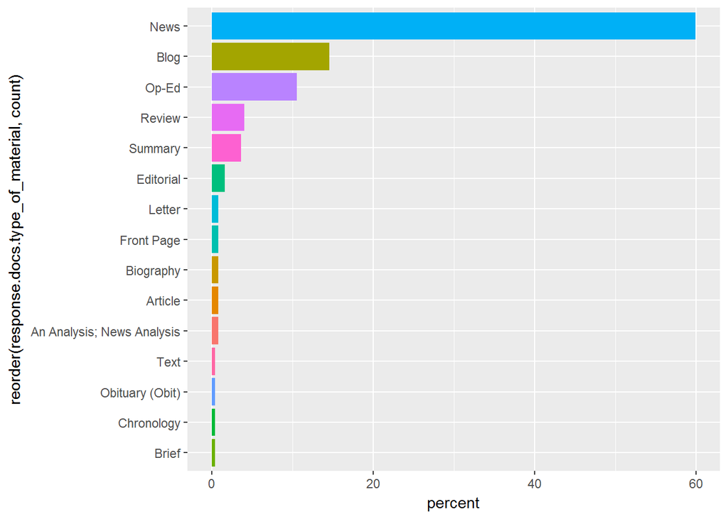

```r
domestic_terroirst_df %>%
   dplyr::group_by(response.docs.type_of_material) %>%
   dplyr::summarize(count=n()) %>%
   dplyr::mutate(percent = (count / sum(count))*100) %>%
  ggplot() +
  geom_bar(aes(y=percent, x=reorder(response.docs.type_of_material,count), fill=response.docs.type_of_material), stat = "identity") + coord_flip()+ theme(legend.position="none")
```

## Author article counts

```r
chooseOne('response.docs.byline.original')
```

```
## # A tibble: 175 x 3
##    response.docs.byline.original     count percent
##    <chr>                             <int>   <dbl>
##  1 By PHILIP SHENON                      8   3.51
##  2 By FRANK RICH                         7   3.07
##  3 By ADAM NAGOURNEY                     5   2.19
##  4 By JIM YARDLEY                        4   1.75
##  5 By ROBERT MACKEY                      4   1.75
##  6 By ADAM NAGOURNEY and JANET ELDER     3   1.32
##  7 By ALESSANDRA STANLEY                 3   1.32
##  8 By ERIC LICHTBLAU                     3   1.32
##  9 By JULIE BOSMAN                       3   1.32
## 10 By AL BAKER                           2   0.877
## # ... with 165 more rows
```

## Attempt at time series results graph

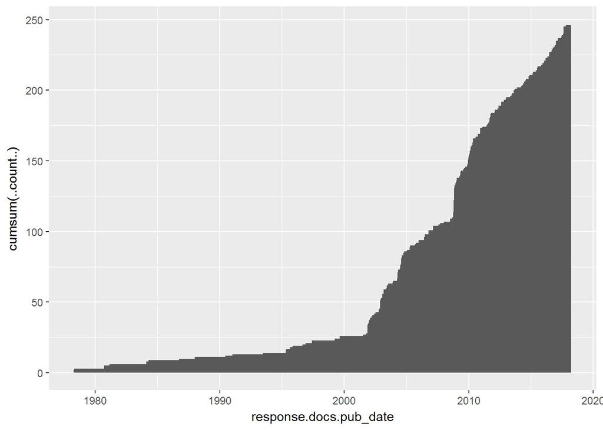

```r
domestic_terroirst_df$response.docs.pub_date <- as.Date(gsub("T.*", "", domestic_terroirst_df$response.docs.pub_date
))

ggplot(domestic_terroirst_df,aes(x=response.docs.pub_date)) +stat_bin(aes(y = cumsum(..count..)),binwidth = 1)
```

## Now that I have an idea of what columns I want, I will make a request for more specified feilds

- Just a test run

```r
cleaner_domestic_terroirst <- list()
fields <- c("headline", "web_url", "abstract","news_desk","word_count" ,"pub_date")
orig_url<- "http://api.nytimes.com/svc/search/v2/articlesearch.json?api-key="
term <- "\"domestic terrorist\""
baseurl <- paste0(orig_url,NYTIMES_KEY,
                  '&q=',term,
                  "&fl=", paste(fields, collapse = ","),
                  sep="")
## Test Run
baseurl <- URLencode(baseurl)
df_2 <- fromJSON(baseurl, flatten = TRUE)

my_df <- df_2$response$docs
dim(my_df)
```

```
## [1] 10 13
```

```r
my_df
```

```
##                                                                                                         web_url
## 1                                     https://www.nytimes.com/aponline/2018/03/29/us/ap-us-austin-bombings.html
## 2                        https://www.nytimes.com/2016/02/28/books/review/a-doubters-almanac-by-ethan-canin.html
## 3                            https://www.nytimes.com/2017/10/19/opinion/columnists/fbi-blacks-civil-rights.html
## 4                      https://www.nytimes.com/2017/08/15/us/politics/right-wing-extremism-charlottesville.html
## 5               https://www.nytimes.com/2017/08/13/us/politics/charlottesville-sessions-justice-department.html
## 6                    https://www.nytimes.com/2017/08/15/opinion/trump-obama-terrorism-charlottesville-isis.html
## 7                  https://www.nytimes.com/2017/08/13/us/charlottesville-protests-white-nationalists-trump.html
## 8  https://www.nytimes.com/2017/06/15/us/politics/before-the-shooting-assailant-began-day-at-ymca-as-usual.html
## 9                                https://www.nytimes.com/2017/08/01/opinion/womens-march-progressives-hate.html
## 10             https://www.nytimes.com/2017/08/13/opinion/university-virginia-uva-protests-charlottesville.html
##                    pub_date   new_desk word_count        score
## 1  2018-03-29T15:39:05+0000       None        339 0.3249993300
## 2      2016-02-28T00:00:00Z BookReview       1263 0.0008542584
## 3  2017-10-19T08:55:01+0000       OpEd        753 0.0006835898
```

[output cut: 62 more lines]

## Conclusion

- I really wanted to go further with this, and may do so during spring break. I will attempt to look into doing some time series analysis on the API results, and compare to other terms.